# practical_exercise_3, Methods 3, 2021, autumn semester

Juli, Jessica, Anja, Magnus, & Astrid

# Exercises and objectives

The objectives of the exercises of this assignment are:  
1) Download and organise the data and model and plot staircase responses based on fits of logistic functions  
2) Fit multilevel models for response times  
3) Fit multilevel models for count data

REMEMBER: In your report, make sure to include code that can reproduce the answers requested in the exercises below (**MAKE A KNITTED VERSION**)  
REMEMBER: This assignment will be part of your final portfolio

## Exercise 1

Go to https://osf.io/ecxsj/files/ and download the files associated with Experiment 2 (there should be 29).  
The data is associated with Experiment 2 of the article at the following DOI https://doi.org/10.1016/j.concog.2019.03.007

1. Put the data from all subjects into a single data frame

```r
df <- read_bulk(
  directory = 'experiment_2/',
  fun = read_csv
  )
```

[output not shown]

[output not shown]

[output not shown]

[output not shown]

[output not shown]

[output not shown]

[output not shown]

[output not shown]

[output not shown]

[output not shown]

[output not shown]

[output not shown]

[output not shown]

[output not shown]

[output not shown]

[output not shown]

[output not shown]

[output not shown]

[output not shown]

[output not shown]

[output not shown]

[output not shown]

[output not shown]

[output not shown]

[output not shown]

[output not shown]

[output not shown]

[output not shown]

[output not shown]

2. Describe the data and construct extra variables from the existing variables
   1. add a variable to the data frame and call it *correct* (have it be a *logical* variable). Assign a 1 to each row where the subject indicated the correct answer and a 0 to each row where the subject indicated the incorrect answer (**Hint:** the variable *obj.resp* indicates whether the subject answered “even”, *e* or “odd”, *o*, and the variable *target_type* indicates what was actually presented.

```r
df$correct <- ifelse(df$obj.resp == "o" & df$target.type == "odd" | df$obj.resp == "e" & df$target.type == "even", 1, 0)

class(df$correct)
```

```
## [1] "numeric"
```

```r
df$correct <- as.logical(df$correct)

glimpse(df)
```

```
## Rows: 18,131
## Columns: 19
## $ trial.type      <chr> "staircase", "staircase", "staircase", "staircase", "…
## $ pas             <dbl> 4, 4, 4, 4, 4, 4, 4, 4, 4, 4, 4, 4, 3, 2, 1, 2, 3, 4,…
## $ trial           <dbl> 0, 1, 2, 3, 4, 5, 6, 7, 8, 9, 10, 11, 12, 13, 14, 15,…
## $ jitter.x        <dbl> -0.34252959, 0.06229222, -0.40575096, -0.36154113, 0.…
## $ jitter.y        <dbl> 0.44888443, 0.02914578, 0.49951833, -0.22243588, 0.41…
## $ odd.digit       <dbl> 9, 9, 7, 7, 7, 7, 7, 7, 9, 9, 7, 9, 5, 3, 9, 5, 9, 3,…
## $ target.contrast <dbl> 1.00000000, 1.00000000, 0.90000000, 0.90000000, 0.800…
## $ target.frames   <dbl> 3, 3, 3, 3, 3, 3, 3, 3, 3, 3, 3, 3, 3, 3, 3, 3, 3, 3,…
## $ cue             <dbl> 29, 29, 29, 29, 29, 29, 29, 29, 29, 29, 29, 29, 0, 0,…
## $ task            <chr> "pairs", "pairs", "pairs", "pairs", "pairs", "pairs",…
## $ target.type     <chr> "odd", "even", "even", "odd", "even", "even", "odd", …
## $ rt.subj         <dbl> 1.7535665, 1.3902975, 0.6862642, 0.6529463, 0.5817340…
## $ rt.obj          <dbl> 1.1578644, 2.4563786, 0.9509719, 0.6203329, 0.9503946…
## $ even.digit      <dbl> 8, 4, 4, 4, 4, 4, 4, 4, 4, 8, 4, 8, 4, 8, 8, 2, 4, 4,…
## $ seed            <dbl> 9817, 9817, 9817, 9817, 9817, 9817, 9817, 9817, 9817,…
## $ obj.resp        <chr> "o", "e", "e", "o", "e", "e", "o", "o", "e", "o", "o"…
## $ subject         <chr> "001", "001", "001", "001", "001", "001", "001", "001…
## $ File            <chr> "001.csv", "001.csv", "001.csv", "001.csv", "001.csv"…
## $ correct         <lgl> TRUE, TRUE, TRUE, TRUE, TRUE, TRUE, TRUE, TRUE, TRUE,…
```

[output not shown]

```r
df$trial.type <- as.factor(df$trial.type)
  #The staircase trial types were only introduced in experiment 2 and is an adaptive procedure that allows to collect more data at the     threshold visibility. It is not explained what a staircase procedure actually is, but it is used at the beginning of the study before    collecting the actual trials.The other trials are experiment trials.

df$pas <- as.factor(df$pas)
  #The Perceptual Awareness Scale, ranging from 1-4.
  #No Experience (NE) -> 1
  #Weak Glimpse (WG) -> 2
  #Almost Clear Experience (ACE) -> 3
  #Clear Experience (CE) -> 4

# trial
  #The text said that each participant performed 864 experiment trials and 18 practice trials beforehand. In the data, it seems that 431   trials are recorded for each participant and a varying number of staircase trials

# target.contrast
  #the opacity of the target relative to the background, it was adjusted to match the threshold of each participant

df$cue <- as.factor(df$cue)
  #a cue of the possible number of digits presented for each trial, i.e. a kind of framing. Repeated 12 times before a new cue was used

df$task <- as.factor(df$task)
  #he 3 types of tasks:
  #Singles
  #Pairs
  #Quadruplets

df$target.type <- as.factor(df$target.type)
  #Whether the target was odd or even

# rt.subj
  #reaction time of the subjective response

df$rt.obj <- as.numeric(df$rt.obj)
  #reaction time of the objective response

df$obj.resp <- as.numeric(df$obj.resp)
  #the subjects answer to whether the number was odd or even

df$subject <- as.factor(df$subject)
  #participantID

# correct
  #our variable indicating with a 1 that the participant answered correctly and a 0 if they answered incorrectly
```

[output not shown]

```r
df.1.2.3 <- df %>%
  filter(trial.type == "staircase")

model.1.2.3 <- glm(correct ~ target.contrast*subject, data = df.1.2.3, family = binomial(link = "logit"))
```

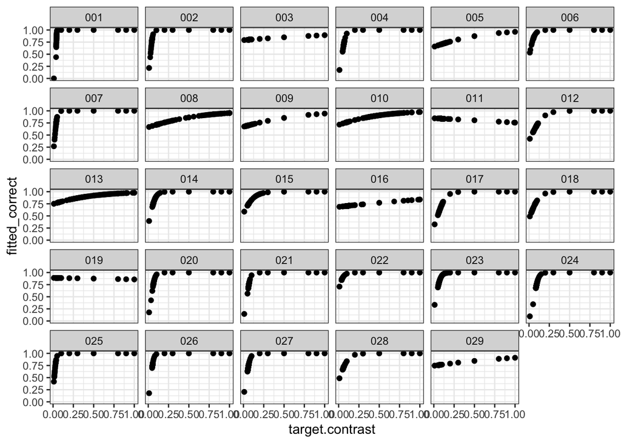

```
iv. on top of those plots, add the estimated functions (on the _target.contrast_ range from 0-1) for each subject based on partial pooling model (use `glmer` from the package `lme4`) where unique intercepts and slopes for _target.contrast_ are modelled for each _subject_
```

```r
df.1.2.3$fitted_correct <- fitted(model.1.2.3)

ggplot(df.1.2.3, aes(x = target.contrast, y = fitted_correct)) +
  geom_point(aes(target.contrast, fitted_correct), color = "black") +
  facet_wrap(~ subject) +
  theme_bw()
```

```r
model.1.2.4 <- glmer(correct ~ target.contrast + (1 + target.contrast|subject), data = df.1.2.3, family = binomial(link = "logit"))
model.1.2.4
```

```
## Generalized linear mixed model fit by maximum likelihood (Laplace
##   Approximation) [glmerMod]
##  Family: binomial  ( logit )
## Formula: correct ~ target.contrast + (1 + target.contrast | subject)
##    Data: df.1.2.3
##       AIC       BIC    logLik  deviance  df.resid
##  5988.467  6021.623 -2989.234  5978.467      5598
## Random effects:
##  Groups  Name            Std.Dev. Corr
##  subject (Intercept)     0.5198
##          target.contrast 6.5090   -0.84
## Number of obs: 5603, groups:  subject, 29
## Fixed Effects:
##     (Intercept)  target.contrast
##          0.5635           8.6844
```

```r
summary(model.1.2.4)
```

```
## Generalized linear mixed model fit by maximum likelihood (Laplace
##   Approximation) [glmerMod]
##  Family: binomial  ( logit )
## Formula: correct ~ target.contrast + (1 + target.contrast | subject)
##    Data: df.1.2.3
##
##      AIC      BIC   logLik deviance df.resid
##   5988.5   6021.6  -2989.2   5978.5     5598
##
## Scaled residuals:
##     Min      1Q  Median      3Q     Max
## -5.7684  0.0068  0.5532  0.5915  0.9254
##
## Random effects:
##  Groups  Name            Variance Std.Dev. Corr
##  subject (Intercept)      0.2702  0.5198
##          target.contrast 42.3674  6.5090   -0.84
## Number of obs: 5603, groups:  subject, 29
##
## Fixed effects:
##                 Estimate Std. Error z value Pr(>|z|)
## (Intercept)       0.5635     0.1572   3.583 0.000339 ***
## target.contrast   8.6844     2.3460   3.702 0.000214 ***
## ---
## Signif. codes:  0 '***' 0.001 '**' 0.01 '*' 0.05 '.' 0.1 ' ' 1
##
## Correlation of Fixed Effects:
##             (Intr)
## trgt.cntrst -0.907
```

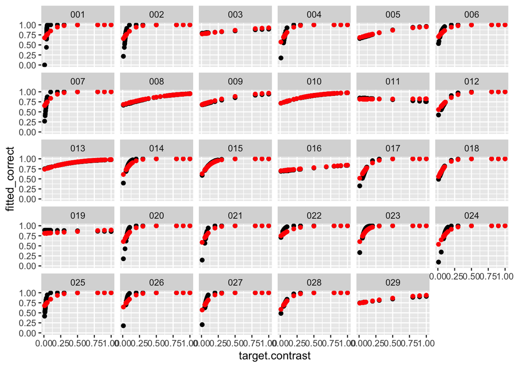

```r
df.1.2.3$fitted_partial <- fitted(model.1.2.4)

ggplot(df.1.2.3, aes(x = target.contrast, y = fitted_correct)) +
  geom_point(aes(target.contrast, fitted_correct), color = "black") +
  geom_point(aes(target.contrast, fitted_partial), color = "red") +
  facet_wrap(~ subject) +
  labs()
```

```r
  theme_bw()
```

[output not shown]

[output cut: 365 more lines]

[output not shown]

```
v. in your own words, describe how the partial pooling model allows for a better fit for each subject
```

```r
#  - partial pooling enables us access information across all of the participants
#  - it improves our estimates throughout individuals
#  - it illustrates individual variance more
```

## Exercise 2

Now we **only** look at the *experiment* trials (*trial.type*)

1. Pick four subjects and plot their Quantile-Quantile (Q-Q) plots for the residuals of their objective response times (*rt.obj*) based on a model where only intercept is modelled

```r
df_experiment <- filter(df, trial.type=="experiment")
df_4participants <- filter(df_experiment, subject=="001" | subject=="002" | subject=="003" | subject=="004")

model.2.1.1 <- lmer(rt.obj ~ 1 + (1 | subject) , data = df_4participants)
model.2.1.1
```

```
## Linear mixed model fit by REML ['lmerMod']
## Formula: rt.obj ~ 1 + (1 | subject)
##    Data: df_4participants
## REML criterion at convergence: 4631.788
## Random effects:
##  Groups   Name        Std.Dev.
##  subject  (Intercept) 0.08787
##  Residual             0.92174
## Number of obs: 1728, groups:  subject, 4
## Fixed Effects:
## (Intercept)
##        0.86
```

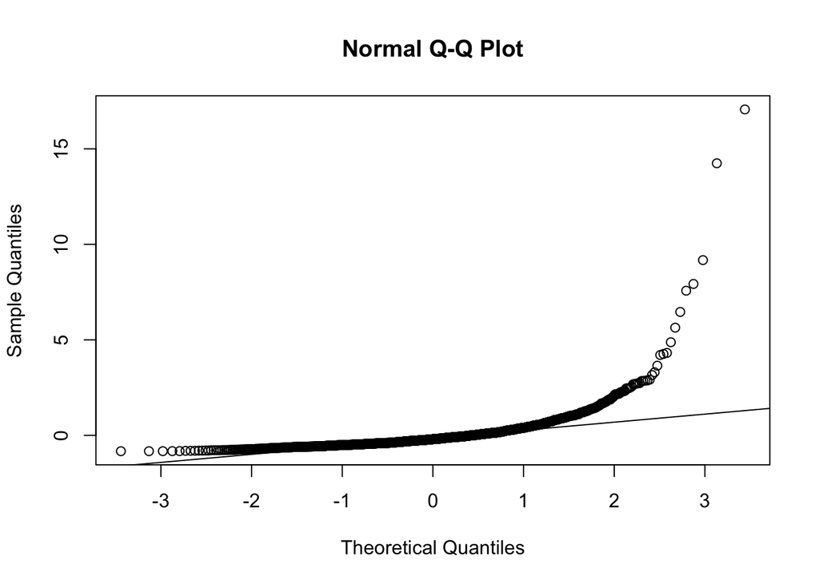

```
i. comment on these

  - it's not normal, it's skewed, it has heavy tails

ii. does a log-transformation of the response time data improve the Q-Q-plots?
```

```r
qqnorm(residuals(model.2.1.1))
qqline(residuals(model.2.1.1))
```

```r
df_4participants$rt.obj.log <- log(df_4participants$rt.obj)
model.2.1.2 <- lmer(rt.obj.log ~ 1 + (1 | subject), data = df_4participants)
model.2.1.2
```

```
## Linear mixed model fit by REML ['lmerMod']
## Formula: rt.obj.log ~ 1 + (1 | subject)
##    Data: df_4participants
## REML criterion at convergence: 4141.282
## Random effects:
##  Groups   Name        Std.Dev.
##  subject  (Intercept) 0.2640
##  Residual             0.7981
## Number of obs: 1728, groups:  subject, 4
## Fixed Effects:
## (Intercept)
##     -0.4534
```

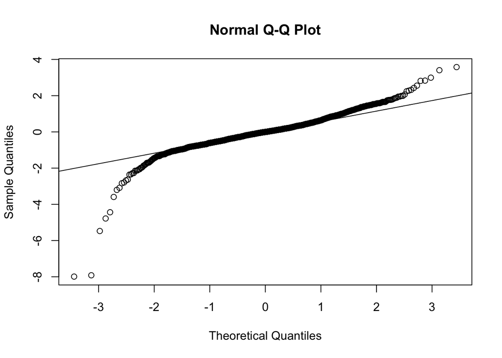

```r
qqnorm(residuals(model.2.1.2))
qqline(residuals(model.2.1.2))
```

```r
#it doesn't improve it, but it looks different
```

2. Now do a partial pooling model modelling objective response times as dependent on *task*? (set `REML=FALSE` in your `lmer`-specification)

```r
model.2.2.1 <- lmer(rt.obj ~ task + (1 | subject), df_experiment, REML=FALSE)

model.2.2.1
```

```
## Linear mixed model fit by maximum likelihood  ['lmerMod']
## Formula: rt.obj ~ task + (1 | subject)
##    Data: df_experiment
##       AIC       BIC    logLik  deviance  df.resid
##  61940.21  61977.39 -30965.11  61930.21     12523
## Random effects:
##  Groups   Name        Std.Dev.
##  subject  (Intercept) 0.3386
##  Residual             2.8590
## Number of obs: 12528, groups:  subject, 29
## Fixed Effects:
##    (Intercept)  taskquadruplet     tasksingles
##         1.1201         -0.1532         -0.1915
```

```
i. which would you include among your random effects and why? (support your choices with relevant measures, taking into account variance explained and number of parameters going into the modelling)

- we chose subject due to individual differences
- variance explained (R squared):
```

```r
r.squaredGLMM(model.2.2.1)
```

```
##               R2m        R2c
## [1,] 0.0008256517 0.01464871
```

[output not shown]

3. Now add *pas* and its interaction with *task* to the fixed effects

```r
model.2.3 <- lmer(rt.obj ~ task * pas + (1 | subject), df_experiment)
```

```
i. how many types of group intercepts (random effects) can you add without ending up with convergence issues or singular fits?
```

```r
model.2.3.1 <- lmer(rt.obj ~ task * pas + (1 | subject) + (1 | correct), df_experiment)
```

```
## boundary (singular) fit: see ?isSingular
```

```r
model.2.3.1
```

```
## Linear mixed model fit by REML ['lmerMod']
## Formula: rt.obj ~ task * pas + (1 | subject) + (1 | correct)
##    Data: df_experiment
## REML criterion at convergence: 61922.81
## Random effects:
##  Groups   Name        Std.Dev.
##  subject  (Intercept) 0.3196
##  correct  (Intercept) 0.0000
##  Residual             2.8560
## Number of obs: 12528, groups:  subject, 29; correct, 2
## Fixed Effects:
##         (Intercept)       taskquadruplet          tasksingles
##             1.33510             -0.32290             -0.21576
##                pas2                 pas3                 pas4
##            -0.13921             -0.33588             -0.57901
## taskquadruplet:pas2     tasksingles:pas2  taskquadruplet:pas3
##             0.22734              0.12531              0.26236
##    tasksingles:pas3  taskquadruplet:pas4     tasksingles:pas4
##             0.09466              0.25825              0.07102
## optimizer (nloptwrap) convergence code: 0 (OK) ; 0 optimizer warnings; 1 lme4 warnings
```

```r
##we have singular fit already from 2 intercepts
```

[output not shown]

```r
model.2.3.2 <- lmer(rt.obj ~ task * pas + (1 | subject) + (1 | correct), df_experiment)
```

```
## boundary (singular) fit: see ?isSingular
```

```r
print(VarCorr(model.2.3.2), comp='Variance')
```

```
##  Groups   Name        Variance
##  subject  (Intercept) 0.10215
##  correct  (Intercept) 0.00000
##  Residual             8.15692
```

```r
?isSingular

# our "dimensions" of the variance-covariance matrix have been estimated as zero
```

```
iii. in your own words - how could you explain why your model would result in a singular fit?

  - because our second intercept is zero
```

## Exercise 3

1. Initialise a new data frame, `data.count`. *count* should indicate the number of times they categorized their experience as *pas* 1-4 for each *task*. I.e. the data frame would have for subject 1: for task:singles, pas1 was used # times, pas2 was used # times, pas3 was used # times and pas4 was used # times. You would then do the same for task:pairs and task:quadruplet

```r
## you can start from this if you want to, but you can also make your own from scratch


counting <- df %>%
  count(subject, task, pas)

counting
```

```
##     subject       task pas   n
## 1       001      pairs   1 109
## 2       001      pairs   2  45
## 3       001      pairs   3   4
## 4       001      pairs   4  12
## 5       001 quadruplet   1 141
## 6       001 quadruplet   2  23
## 7       001 quadruplet   3   3
## 8       001 quadruplet   4   1
## 9       001    singles   1  43
## 10      001    singles   2  87
## 11      001    singles   3  35
## 12      001    singles   4   3
## 13      002      pairs   1  84
## 14      002      pairs   2  82
```

[output cut: 326 more lines]

```r
##create a df out of our table
data.count <- as.data.frame.matrix(counting)

data.count <- data.count %>%
   rename(count = n)

data.count$count <-  as.numeric(data.count$count)
data.count$pas <-  as.numeric(data.count$pas)
data.count$task <-  as.factor(data.count$task)
data.count$subject <-  as.numeric(data.count$subject)

glimpse(data.count)
```

```
## Rows: 340
## Columns: 4
## $ subject <dbl> 1, 1, 1, 1, 1, 1, 1, 1, 1, 1, 1, 1, 2, 2, 2, 2, 2, 2, 2, 2, 2…
## $ task    <fct> pairs, pairs, pairs, pairs, quadruplet, quadruplet, quadruple…
## $ pas     <dbl> 1, 2, 3, 4, 1, 2, 3, 4, 1, 2, 3, 4, 1, 2, 3, 1, 2, 4, 1, 2, 3…
## $ count   <dbl> 109, 45, 4, 12, 141, 23, 3, 1, 43, 87, 35, 3, 84, 82, 5, 67, …
```

2. Now fit a multilevel model that models a unique “slope” for *pas* for each *subject* with the interaction between *pas* and *task* and their main effects being modelled
   1. which family should be used?

```r
data.count$count <-  as.numeric(data.count$count)
data.count$pas <-  as.factor(data.count$pas)
data.count$task <-  as.factor(data.count$task)
data.count$subject <-  as.factor(data.count$subject)

model.3.2.0 <- glmer(count ~ pas*task + (1+pas|subject), family = poisson, data = data.count)
model.3.2.0
```

```
## Generalized linear mixed model fit by maximum likelihood (Laplace
##   Approximation) [glmerMod]
##  Family: poisson  ( log )
## Formula: count ~ pas * task + (1 + pas | subject)
##    Data: data.count
##       AIC       BIC    logLik  deviance  df.resid
##  3148.441  3232.678 -1552.220  3104.441       318
## Random effects:
##  Groups  Name        Std.Dev. Corr
##  subject (Intercept) 0.5764
##          pas2        0.6165   -0.75
##          pas3        1.0934   -0.84  0.63
##          pas4        1.5405   -0.86  0.42  0.72
## Number of obs: 340, groups:  subject, 29
## Fixed Effects:
##         (Intercept)                 pas2                 pas3
##             4.03550             -0.02364             -0.51322
##                pas4       taskquadruplet          tasksingles
##            -0.77251              0.11495             -0.23090
## pas2:taskquadruplet  pas3:taskquadruplet  pas4:taskquadruplet
##            -0.11377             -0.20912             -0.21508
##    pas2:tasksingles     pas3:tasksingles     pas4:tasksingles
##             0.19537              0.24291              0.56339
## optimizer (Nelder_Mead) convergence code: 0 (OK) ; 0 optimizer warnings; 1 lme4 warnings
```

```r
summary(model.3.2.0)
```

```
## Generalized linear mixed model fit by maximum likelihood (Laplace
##   Approximation) [glmerMod]
##  Family: poisson  ( log )
## Formula: count ~ pas * task + (1 + pas | subject)
##    Data: data.count
##
##      AIC      BIC   logLik deviance df.resid
##   3148.4   3232.7  -1552.2   3104.4      318
##
## Scaled residuals:
##     Min      1Q  Median      3Q     Max
## -4.3872 -0.7853 -0.0472  0.7552  6.5435
##
## Random effects:
##  Groups  Name        Variance Std.Dev. Corr
##  subject (Intercept) 0.3322   0.5764
##          pas2        0.3801   0.6165   -0.75
##          pas3        1.1956   1.0934   -0.84  0.63
##          pas4        2.3731   1.5405   -0.86  0.42  0.72
## Number of obs: 340, groups:  subject, 29
##
## Fixed effects:
##                     Estimate Std. Error z value Pr(>|z|)
## (Intercept)          4.03550    0.10974  36.773  < 2e-16 ***
## pas2                -0.02364    0.11960  -0.198 0.843332
## pas3                -0.51322    0.20715  -2.478 0.013230 *
## pas4                -0.77251    0.29073  -2.657 0.007880 **
## taskquadruplet       0.11495    0.03127   3.676 0.000237 ***
## tasksingles         -0.23090    0.03418  -6.755 1.43e-11 ***
## pas2:taskquadruplet -0.11377    0.04605  -2.470 0.013500 *
## pas3:taskquadruplet -0.20912    0.05287  -3.956 7.63e-05 ***
## pas4:taskquadruplet -0.21508    0.05230  -4.113 3.91e-05 ***
## pas2:tasksingles     0.19537    0.04830   4.045 5.23e-05 ***
## pas3:tasksingles     0.24291    0.05369   4.524 6.07e-06 ***
## pas4:tasksingles     0.56339    0.05101  11.044  < 2e-16 ***
## ---
## Signif. codes:  0 '***' 0.001 '**' 0.01 '*' 0.05 '.' 0.1 ' ' 1
##
## Correlation of Fixed Effects:
##             (Intr) pas2   pas3   pas4   tskqdr tsksng ps2:tskq ps3:tskq
```

[output cut: 10 more lines]

```
## ps4:tsksngl  0.092 -0.085 -0.049 -0.091 -0.324 -0.670  0.220    0.192
##             ps4:tskq ps2:tsks ps3:tsks
## pas2
## pas3
## pas4
## taskqudrplt
## tasksingles
## ps2:tskqdrp
## ps3:tskqdrp
## ps4:tskqdrp
## ps2:tsksngl  0.205
## ps3:tsksngl  0.184    0.451
## ps4:tsksngl  0.507    0.474    0.427
## optimizer (Nelder_Mead) convergence code: 0 (OK)
## Model failed to converge with max|grad| = 0.00343245 (tol = 0.002, component 1)
```

```r
# Poisson family used for count data
```

[output not shown]

```r
model.3.2.0 <- glmer(count ~ pas*task + (1+pas|subject), family = poisson, data = data.count, control = glmerControl(optimizer="bobyqa"))
model.3.2.0
```

```
## Generalized linear mixed model fit by maximum likelihood (Laplace
##   Approximation) [glmerMod]
##  Family: poisson  ( log )
## Formula: count ~ pas * task + (1 + pas | subject)
##    Data: data.count
##       AIC       BIC    logLik  deviance  df.resid
##  3148.441  3232.678 -1552.220  3104.441       318
## Random effects:
##  Groups  Name        Std.Dev. Corr
##  subject (Intercept) 0.5765
##          pas2        0.6167   -0.75
##          pas3        1.0936   -0.84  0.63
##          pas4        1.5407   -0.86  0.42  0.72
## Number of obs: 340, groups:  subject, 29
## Fixed Effects:
##         (Intercept)                 pas2                 pas3
##             4.03570             -0.02378             -0.51365
##                pas4       taskquadruplet          tasksingles
##            -0.77292              0.11490             -0.23095
## pas2:taskquadruplet  pas3:taskquadruplet  pas4:taskquadruplet
##            -0.11375             -0.20901             -0.21500
##    pas2:tasksingles     pas3:tasksingles     pas4:tasksingles
##             0.19536              0.24299              0.56346
```

```r
summary(model.3.2.0)
```

```
## Generalized linear mixed model fit by maximum likelihood (Laplace
##   Approximation) [glmerMod]
##  Family: poisson  ( log )
## Formula: count ~ pas * task + (1 + pas | subject)
##    Data: data.count
## Control: glmerControl(optimizer = "bobyqa")
##
##      AIC      BIC   logLik deviance df.resid
##   3148.4   3232.7  -1552.2   3104.4      318
##
## Scaled residuals:
##     Min      1Q  Median      3Q     Max
## -4.3871 -0.7853 -0.0469  0.7550  6.5438
##
## Random effects:
##  Groups  Name        Variance Std.Dev. Corr
##  subject (Intercept) 0.3324   0.5765
##          pas2        0.3803   0.6167   -0.75
##          pas3        1.1960   1.0936   -0.84  0.63
##          pas4        2.3736   1.5407   -0.86  0.42  0.72
## Number of obs: 340, groups:  subject, 29
##
## Fixed effects:
##                     Estimate Std. Error z value Pr(>|z|)
## (Intercept)          4.03570    0.10976  36.769  < 2e-16 ***
## pas2                -0.02378    0.11963  -0.199 0.842458
## pas3                -0.51365    0.20718  -2.479 0.013166 *
## pas4                -0.77292    0.29075  -2.658 0.007853 **
## taskquadruplet       0.11490    0.03127   3.674 0.000239 ***
## tasksingles         -0.23095    0.03418  -6.756 1.42e-11 ***
## pas2:taskquadruplet -0.11375    0.04605  -2.470 0.013508 *
## pas3:taskquadruplet -0.20901    0.05287  -3.954 7.70e-05 ***
## pas4:taskquadruplet -0.21500    0.05230  -4.111 3.94e-05 ***
## pas2:tasksingles     0.19536    0.04830   4.045 5.23e-05 ***
## pas3:tasksingles     0.24299    0.05369   4.526 6.02e-06 ***
## pas4:tasksingles     0.56346    0.05101  11.045  < 2e-16 ***
## ---
## Signif. codes:  0 '***' 0.001 '**' 0.01 '*' 0.05 '.' 0.1 ' ' 1
##
## Correlation of Fixed Effects:
```

[output cut: 9 more lines]

```
## ps2:tsksngl  0.098 -0.188 -0.052 -0.037 -0.342 -0.708  0.490    0.203
## ps3:tsksngl  0.088 -0.080 -0.124 -0.033 -0.308 -0.637  0.209    0.486
## ps4:tsksngl  0.092 -0.085 -0.049 -0.091 -0.324 -0.670  0.220    0.192
##             ps4:tskq ps2:tsks ps3:tsks
## pas2
## pas3
## pas4
## taskqudrplt
## tasksingles
## ps2:tskqdrp
## ps3:tskqdrp
## ps4:tskqdrp
## ps2:tsksngl  0.205
## ps3:tsksngl  0.184    0.451
## ps4:tsksngl  0.507    0.474    0.427
```

```
iv. when you have a converging fit - fit a model with only the main effects of _pas_ and _task_. Compare this with the model that also includes the interaction
```

```r
model.3.2.4 <- glmer(count ~ pas + task + (1+pas|subject), family = poisson, data = data.count, control = glmerControl(optimizer="bobyqa"))
```

```
v. indicate which of the two models, you would choose and why
```

```r
#residuals
residuals_model1 <- residuals(model.3.2.0)
residuals_model2 <- residuals(model.3.2.4)
#residual variance
rvar_model1<- sum((residuals_model1)^2)
rvar_model2<- sum((residuals_model2)^2)
#residual standard deviation
sd_model1<- sqrt((sum(residuals_model1)^2/length(residuals_model1)-2))
sd_model2<- sqrt((sum(residuals_model2)^2/length(residuals_model2)-2))
#AICs
AICs <- AIC(model.3.2.0, model.3.2.4) #model1 = with interaction, model2 = without interaction

#Table
tibble("model"=c("With Interaction","Without Interaction"), "residual variance"=c(rvar_model1, rvar_model2), "residual sd"=c(sd_model1, sd_model2), "AIC"=c(AIC(model.3.2.0), AIC(model.3.2.4)))
```

```
## # A tibble: 2 x 4
##   model               `residual variance` `residual sd`   AIC
##   <chr>                             <dbl>         <dbl> <dbl>
## 1 With Interaction                   699.         0.847 3148.
## 2 Without Interaction                962.         1.32  3399.
```

```r
## The model with interaction has a lower residual variance and AIC and residual SD therefore it is the model we would chose
```

```
vi. based on your chosen model - write a short report on what this says about the distribution of ratings as dependent on _pas_ and _task_
```

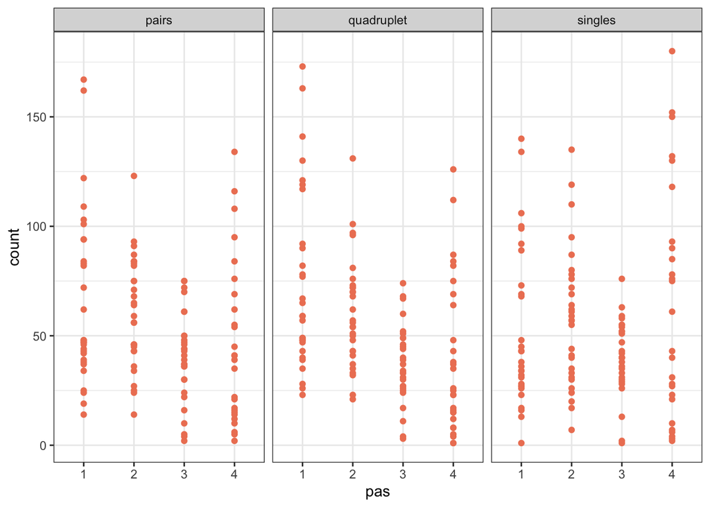

```r
ggplot(data.count, aes(x = pas, y = count)) +
  geom_point(aes(pas, count), color = "salmon2") +
  facet_wrap(~ task) +
  theme_bw()
```

```r
# We used this plot to visualize ratings based on pas and task. Across task, the ratings appear the same. Across pas, participants saw singles more clearly which makes sense because they were looking at less. But between pairs and quadruplet, they were very similar.
```

```
vii. include a plot that shows the estimated amount of ratings for four subjects of your choosing
```